# Generalized Linear Models - HW 3

Jan Tychtl

#### Introduction

The aim of this assignment is to practice constructing linear models. You will start with a simple linear model.

You will evaluate and interpret it (1p).

Consequently, your task will be to improve this model using generalized linear models (GLMs) and feature transformations.

You will get 1p for proposal and evaluation of GLM (family, evaluation, interpretation),

1p for correct feature transformations,

1p for proposal and justification of the final model and eventually,

1p for comprehensive evaluation of all the model improvements (ablation study through cross-validation, note that the previous evaluations must be done without cross-validation).

#### Input data

In this assignment, you will work with a student dataset. The dataset contains 200 samples and 4 features:

*num_awards* is the outcome variable and indicates the number of awards earned by students in a year, *math* is a continuous predictor variable and represents students’ scores on their math final exam, *prog* is a categorical predictor variable with three levels indicating the type of program in which the students were enrolled (1 = “General”, 2 = “Academic” and 3 = “Vocational”), and *work* is a continuous predictor that gives the number of hours that students spent at work on average per week.

#### Load the necessary libraries and the dataset

#### Simple linear model

Let us start with an ordinary linear model with no feature transformations. Explain how far the model works (does it meet formal assumptions?, does it overcome the null model?). Which predictors would you keep there and which of them are not useful? Use the standard evaluation procedures that we have for linear models.

```r
simple_lm <- lm(num_awards ~ ., d)
summary(simple_lm)
```

```
##
## Call:
## lm(formula = num_awards ~ ., data = d)
##
## Residuals:
##     Min      1Q  Median      3Q     Max
## -1.7526 -0.5680 -0.0862  0.2979  4.4411
##
## Coefficients:
##              Estimate Std. Error t value Pr(>|t|)
## (Intercept) -2.536344   0.481442  -5.268 3.61e-07 ***
## prog         0.109815   0.095972   1.144    0.254
## math         0.056617   0.007130   7.941 1.53e-13 ***
## work        -0.002379   0.005807  -0.410    0.682
## ---
## Signif. codes:  0 '***' 0.001 '**' 0.01 '*' 0.05 '.' 0.1 ' ' 1
##
## Residual standard error: 0.9168 on 196 degrees of freedom
## Multiple R-squared:  0.2533, Adjusted R-squared:  0.2418
## F-statistic: 22.16 on 3 and 196 DF,  p-value: 2.133e-12
```

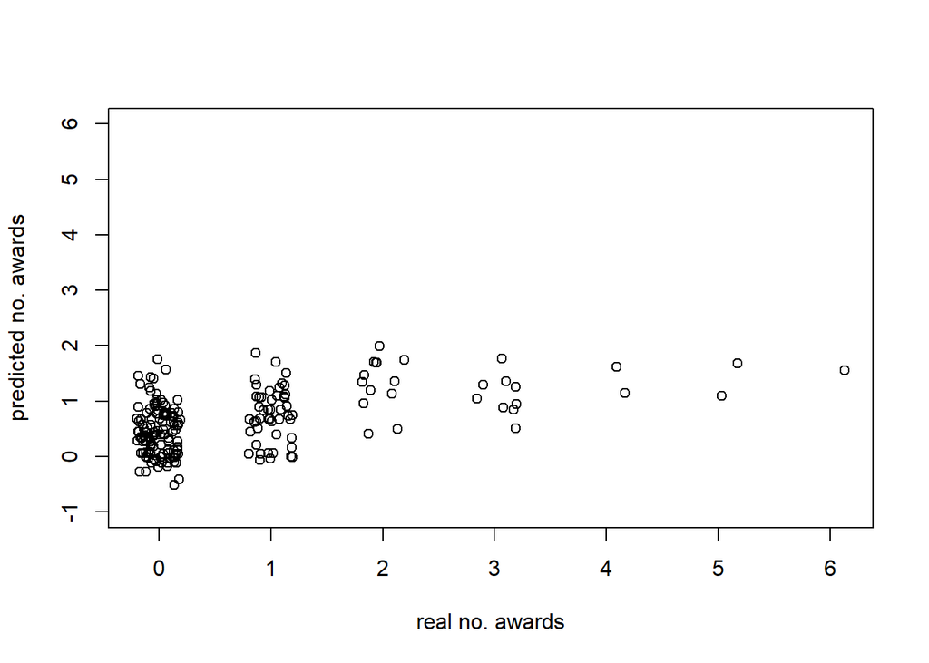

```r
# What are the shortcomings of the simple regression?
plot(d$num_awards+runif(nrow(d),-0.2,0.2),
     predict(simple_lm, d),
     ylab = 'predicted no. awards',
     xlab = 'real no. awards',
     ylim = c(-1, 6))
```

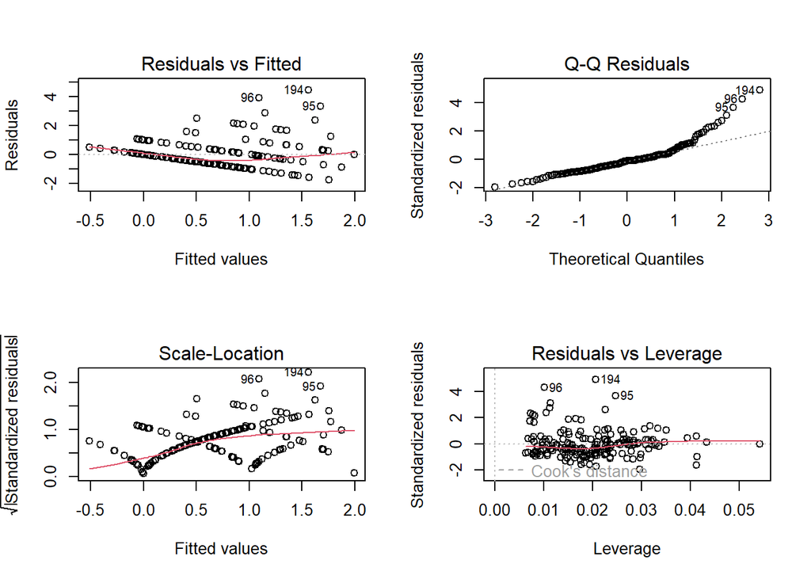

```r
par(mfrow=c(2, 2))
plot(simple_lm)
```

```
## Analysis of Variance Table
##
## Response: num_awards
##            Df  Sum Sq Mean Sq F value   Pr(>F)
## math        1  54.509  54.509 64.8496 7.69e-14 ***
## prog        1   1.222   1.222  1.4536   0.2294
## work        1   0.141   0.141  0.1679   0.6824
## Residuals 196 164.748   0.841
## ---
## Signif. codes:  0 '***' 0.001 '**' 0.01 '*' 0.05 '.' 0.1 ' ' 1
```

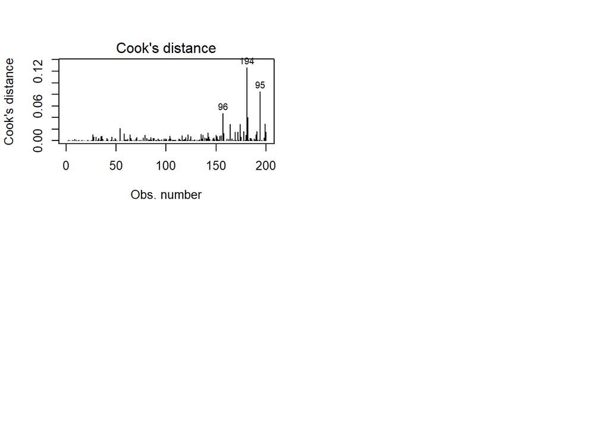

```r
plot(simple_lm,4)

# Refer to the lectures what this call measures
anova(lm(num_awards ~ math + prog + work, d))
```

## (1p) Verbal summary of the simple model:

### Assumptions

When we look at our graphs, we can see that we have several problems with our current dataset. More specifically we have violated some formal assumptions Violated. Let’s go through them:

#### Residuals vs. Fitted

The points are not evenly scattered around the zero line. We can observe a slight curve, and the spread of the residuals increases as the fitted values increase (fanning out), which indicates heteroscedasticity (non-constant variance).

#### QQ Plot

The residuals deviate significantly from the diagonal line, especially at the higher end. This indicates that the residuals are not normally distributed, which is a common issue when modeling count data with OLS.

#### Scale-Location

This plot confirms the heteroscedasticity, showing that the variance of the residuals increases with the level of the fitted values.

## Values

#### Overall model performance

The model’s F-statistic is high (22.16) and the p-value is extremely small (2.133e-12). This means the model as a whole is statistically significant and performs much better than an intercept-only (null) model.

#### R-Squared

The Adjusted R-squared is 0.2418, indicating that the model explains approximately 24.2% of the variance in the number of awards.

#### Predictors

The math variable is a highly significant predictor (p = 1.53e-13). However, prog (p = 0.254) and work (p = 0.682) are not statistically significant at the α=0.05 level. The anova() output confirms that math explains the vast majority of the variance captured by the model.

## Anova output

The anova output tells us that the math is by far the largest and most significant predictor of the variance. The rest of them are not that significant, because of their large p-values (>0.05)

## Overall summary

The simple OLS linear model is statistically significant, but it suffers from major shortcomings. These issues stem from the nature of the outcome variable (num_awards), which is count data (non-negative integers). This leads directly to the violation of OLS assumptions we observed: non-normal residuals and heteroscedasticity.

##### Generalized linear model

Now, the goal is to implement a generalized linear model that conceptually fits the given task. Do not transform the predictors yet, use them as they are, or omit them from the model. Once you obtain your model, interpret the effect of the *math* predictor on the outcome. How (according to your model) increasing a math score by one point affects the number of awards won?

Explain why the model overcomes the previous linear model, or justify that the generalized model is not needed. Compare the models theoretically as well as technically in terms of a proper quality measure. Note: The difference between the models cannot be statistically tested.

# (1p) GLM verbal summary:

Since the outcome variable num_awards is a count of non-negative integers, a Generalized Linear Model (GLM) from the Poisson family is a more appropriate choice than OLS. The Poisson model uses a log link function (log(μ)=β0+β1x1+…), which ensures that the predicted values (the expected count, μ) are always non-negative.

But Poisson assumes that mean and variance equal. We need to check that. If we find overdispersion we can use Negative Bionomial instead.

```r
# GLM with Poisson family
mean_num <- mean(d$num_awards)
var_num  <- var(d$num_awards)
cat("mean =", mean_num, "variance =", var_num, "\n")
```

```
## mean = 0.63 variance = 1.108643
```

```r
# Fit Poisson GLM
glm_poisson <- glm(num_awards ~ prog + math + work, data = d, family = poisson(link = "log"))
summary(glm_poisson)
```

```
##
## Call:
## glm(formula = num_awards ~ prog + math + work, family = poisson(link = "log"),
##     data = d)
##
## Coefficients:
##              Estimate Std. Error z value Pr(>|z|)
## (Intercept) -5.417786   0.707232  -7.661 1.85e-14 ***
## prog         0.118932   0.163815   0.726    0.468
## math         0.085209   0.009675   8.807  < 2e-16 ***
## work        -0.007073   0.008574  -0.825    0.409
## ---
## Signif. codes:  0 '***' 0.001 '**' 0.01 '*' 0.05 '.' 0.1 ' ' 1
##
## (Dispersion parameter for poisson family taken to be 1)
##
##     Null deviance: 287.67  on 199  degrees of freedom
## Residual deviance: 202.77  on 196  degrees of freedom
## AIC: 386.82
##
## Number of Fisher Scoring iterations: 6
```

```r
AIC(simple_lm, glm_poisson)
```

```
##             df      AIC
## simple_lm    5 538.7950
## glm_poisson  4 386.8224
```

The Poisson model is a significant improvement. Its AIC (386.8) is substantially lower than the simple_lm (538.8), indicating a much better relative fit. The residual deviance (202.77 on 196 df) is also much lower than the null deviance (287.67).

When it comes to predictors, we can see that the math predictor is highly significant ( p-value is less than 0.001) while the other predictors seem to be non-significant (p-value is over 0.4).

The estimated coefficient for math is β_math=0.085209. In the Poisson GLM with a log link, the exponentiated coefficient represents the factor change in the expected count: e^(B_math) = e^0.085209 = 1.0889.

This means that, for a one-point increase in the math score, the expected number of awards won increases by a factor of approximately 1.089, or about an 8.9% increase, holding other predictors constant.

```r
dispersiontest(glm_poisson)
```

```
##
##  Overdispersion test
##
## data:  glm_poisson
## z = 1.423, p-value = 0.07737
## alternative hypothesis: true dispersion is greater than 1
## sample estimates:
## dispersion
##   1.165886
```

A key assumption of the Poisson model is that the mean and variance of the data are equal.

The raw data shows overdispersion (variance > mean): mean = 0.63, variance = 1.11. And the dispersiontest (p = 0.077) suggests this overdispersion is not statistically significant at the α=0.05 level, though it is borderline.

```r
# Negative Binomial GLM (handles overdispersion)
glm_nb <- MASS::glm.nb(num_awards ~ math + prog + work, data = d)
summary(glm_nb)
```

```
##
## Call:
## MASS::glm.nb(formula = num_awards ~ math + prog + work, data = d,
##     init.theta = 3.642871986, link = log)
##
## Coefficients:
##              Estimate Std. Error z value Pr(>|z|)
## (Intercept) -5.566265   0.804305  -6.921 4.50e-12 ***
## math         0.087465   0.011082   7.893 2.95e-15 ***
## prog         0.138180   0.179289   0.771    0.441
## work        -0.008452   0.009560  -0.884    0.377
## ---
## Signif. codes:  0 '***' 0.001 '**' 0.01 '*' 0.05 '.' 0.1 ' ' 1
##
## (Dispersion parameter for Negative Binomial(3.6429) family taken to be 1)
##
##     Null deviance: 242.60  on 199  degrees of freedom
## Residual deviance: 170.71  on 196  degrees of freedom
## AIC: 384.94
##
## Number of Fisher Scoring iterations: 1
##
##
##               Theta:  3.64
##           Std. Err.:  2.34
##
##  2 x log-likelihood:  -374.936
```

```r
AIC(simple_lm, glm_poisson, glm_nb)
```

```
##             df      AIC
## simple_lm    5 538.7950
## glm_poisson  4 386.8224
## glm_nb       5 384.9361
```

Because overdispersion is a “almost” possibility, we also tested a Negative Binomial (NB) GLM (glm_nb), which is designed to handle this. The NB model shows a slightly better AIC (384.9) than the Poisson model (386.8) for the cost of one extra parameter (df=5 vs df=4). Given the weak evidence for overdispersion, the Poisson model is still a justifiable choice at this stage.

### Feature transformations and final model

*prog* and *work* did not prove to be effective predictors so far. Visualize these predictors as well as their relationship with the outcome variable. Based on the observations, propose suitable transformations for them (or, justify that they are truly uninformative for prediction of *num_awards*) and implement them into the best model found by now. Use the *compareGLM()* function to validate that your new GLMs indeed improved over the simple one.

```r
typeof(d$prog)
```

```
## [1] "integer"
```

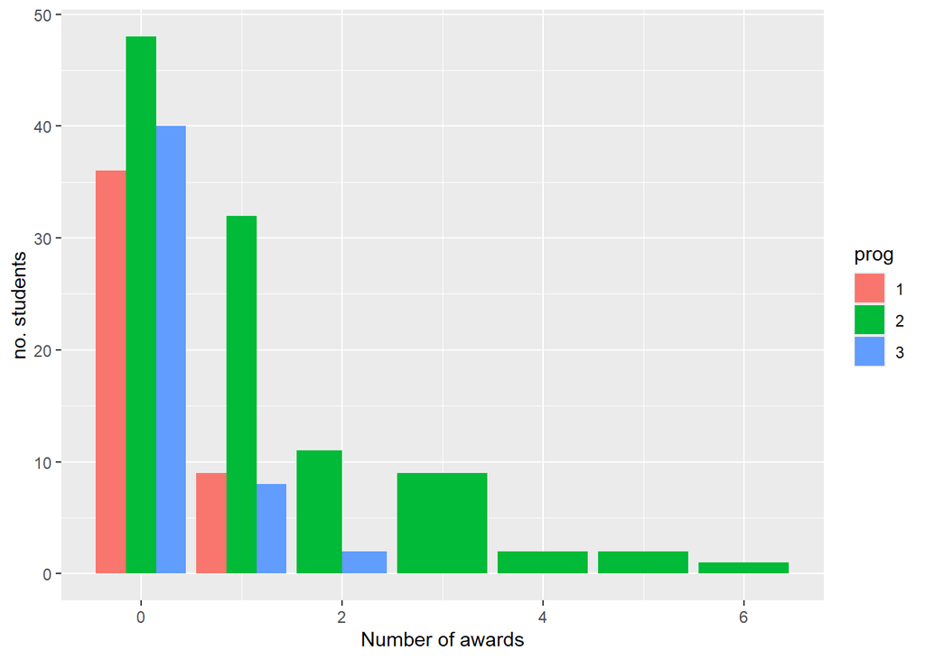

```r
d %>%
  mutate(prog=as.factor(prog)) %>%
  group_by(num_awards, prog) %>%
  summarise(count=n()) %>%
  ggplot(aes(x = num_awards, y=count, fill = prog)) +
  geom_col(position="dodge") +
  xlab("Number of awards") +
  ylab("no. students")
```

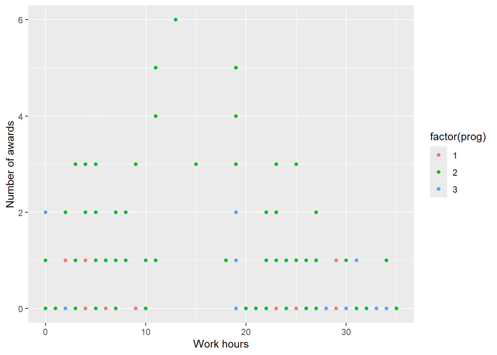

```r
d %>%
  ggplot(aes(x = work, y = num_awards, color = factor(prog))) +
  geom_point() +
  xlab("Work hours") +
  ylab("Number of awards")
```

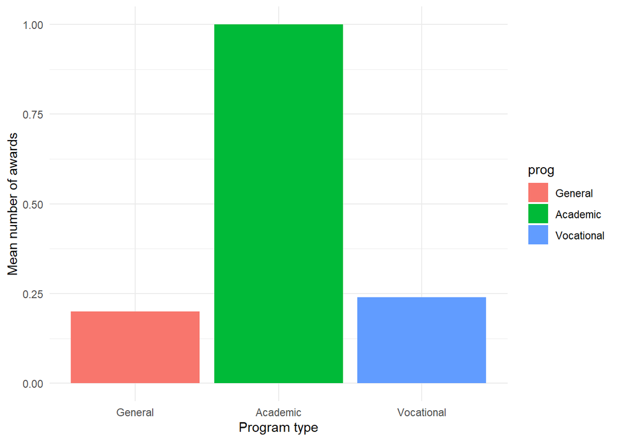

```r
# Categorical variable prog
d %>%
  mutate(prog = factor(prog, labels = c("General", "Academic", "Vocational"))) %>%
  group_by(prog) %>%
  summarise(mean_awards = mean(num_awards)) %>%
  ggplot(aes(x = prog, y = mean_awards, fill = prog)) +
  geom_col() +
  ylab("Mean number of awards") +
  xlab("Program type") +
  theme_minimal()
```

# Verbal summary here of feature selection (2p):

The plots reveal two major issues with how the predictors prog and work are being used:

#### Prog

The variable prog is categorical (1=“General”, 2=“Academic”, 3=“Vocational”), but it was incorrectly treated as a continuous numeric variable in the first models.

This implies a false linear relationship (e.g., that “Vocational” has double the effect of “Academic”). The bar chart confirms that the three groups have different mean award levels, with “Academic” (2) having a much higher mean than “General” (1) or “Vocational” (3).

The correct approach is to convert prog to a factor so the model treats them as distinct groups.

#### Work

The scatter plot of work vs. num_awards shows a clear non-linear relationship. The number of awards appears to peak for students working 10-25 hours per week and is lower for students who work 0 hours or 30+ hours.

A simple linear term cannot capture this curve. This relationship can be modeled using either a polynomial (quadratic) term or more flexibly a spline.

##### Ablation study through cross-validation

Recap all the models considered previously and evaluate them through cross-validation. You can start with the most simple null model and gradually add the previously discussed improvements. See their role in terms of MAE, RMSE and other commonly used criteria. The procedure outlined below proposes to work with *train* function from *caret* package, you can only add more models to evaluate and compare.

```r
train_control <- trainControl(method = "cv", number = 10)
set.seed(5)

# Model 1: Just intercept
m_null <- train(x = data.frame(rep(1, nrow(d))),
          y = d$num_awards,
          method = "lm",
          trControl = train_control)

# Model 2: Simple Linear Model (OLS)
# (prog is still treated as numeric)
m_lm <- train(num_awards ~ math + prog + work,
              data = d,
              method = "lm",
              trControl = train_control)

# Model 3: Base Poisson GLM
# (prog is still numeric, just changing family)
m_glm_base <- train(num_awards ~ math + prog + work,
                    data = d,
                    method = "glm",
                    family = "poisson",
                    trControl = train_control)

# Model 4: Poisson GLM with prog as Factor
# (The first key improvement)
m_glm_factor <- train(num_awards ~ math + as.factor(prog) + work,
                      data = d,
                      method = "glm",
                      family = "poisson",
                      trControl = train_control)

# Model 5: Poisson GLM (Factor prog) + Quadratic Work
# (Testing the poly(work, 2) hypothesis)
m_glm_quad <- train(num_awards ~ math + as.factor(prog) + poly(work, 2),
                    data = d,
                    method = "glm",
                    family = "poisson",
                    trControl = train_control)

# Model 6: Poisson GLM (Factor prog) + Spline Work
# (Testing the ns(work, 3) hypothesis)
m_glm_spline <- train(num_awards ~ math + as.factor(prog) + splines::ns(work, df = 4),
                      data = d,
                      method = "glm",
                      family = "poisson",
                      trControl = train_control)

### ------- Negative Binomial testing for curiosity

# Model 7: NB
m_nb <- train(num_awards ~ math + prog + work,
                     data = d,
                     method = "glm.nb",
                     trControl = train_control)

# Model 8: NB (Factor prog)
m_nb_factor <- train(num_awards ~ math + as.factor(prog) + work,
                     data = d,
                     method = "glm.nb",
                     trControl = train_control)

# Model 9: NB (Factor prog) + Quadratic Work
m_nb_quad <- train(num_awards ~ math + as.factor(prog) + poly(work, 2),
                   data = d,
                   method = "glm.nb",
                   trControl = train_control)

# Model 10: NB (Factor prog) + Spline Work
m_nb_spline <- train(num_awards ~ math + as.factor(prog) + splines::ns(work, df = 3),
                     data = d,
                     method = "glm.nb",
                     trControl = train_control)

# --- Re-create the model_list with ALL models ---
model_list <- resamples(list(
  BASE = m_null,
  SIMPLE_LM = m_lm,
  GLM_BASE = m_glm_base,
  GLM_BASE_NB = m_nb,
  GLM_FACTOR_NB = m_nb_factor,
  GLM_FACTOR_PROG = m_glm_factor,
  GLM_QUAD_POISSON = m_glm_quad,
  GLM_QUAD_NB = m_nb_quad,
  GLM_SPLINE_POISSON = m_glm_spline,
  GLM_SPLINE_NB = m_nb_spline
))

# Print the new summary
summary(model_list)
```

```
##
## Call:
## summary.resamples(object = model_list)
##
## Models: BASE, SIMPLE_LM, GLM_BASE, GLM_BASE_NB, GLM_FACTOR_NB, GLM_FACTOR_PROG, GLM_QUAD_POISSON, GLM_QUAD_NB, GLM_SPLINE_POISSON, GLM_SPLINE_NB
## Number of resamples: 10
##
## MAE
##                         Min.   1st Qu.    Median      Mean   3rd Qu.      Max.
## BASE               0.6256983 0.7118348 0.7936624 0.7842199 0.8307183 0.9411111
## SIMPLE_LM          0.4499490 0.5532509 0.6496153 0.6347075 0.7023931 0.7745105
## GLM_BASE           0.5025536 0.5441754 0.6180551 0.6245066 0.6545272 0.8482929
## GLM_BASE_NB        0.4117915 0.5863256 0.6368965 0.6305028 0.6850046 0.8169747
## GLM_FACTOR_NB      0.3423194 0.5617425 0.6311079 0.6016045 0.6741632 0.7554677
## GLM_FACTOR_PROG    0.4839428 0.4985548 0.5385914 0.5995329 0.7143288 0.8166795
## GLM_QUAD_POISSON   0.4879469 0.5320392 0.5821033 0.5874382 0.6525821 0.6886868
## GLM_QUAD_NB        0.3561224 0.5025464 0.5820628 0.5836598 0.6899835 0.7581178
## GLM_SPLINE_POISSON 0.4312847 0.5005149 0.5728676 0.5909529 0.6421784 0.8022824
## GLM_SPLINE_NB      0.4454449 0.5234211 0.6135456 0.6029772 0.6555512 0.7857434
##                    NA's
## BASE                  0
## SIMPLE_LM             0
## GLM_BASE              0
## GLM_BASE_NB           0
## GLM_FACTOR_NB         0
## GLM_FACTOR_PROG       0
## GLM_QUAD_POISSON      0
## GLM_QUAD_NB           0
## GLM_SPLINE_POISSON    0
## GLM_SPLINE_NB         0
##
## RMSE
##                         Min.   1st Qu.    Median      Mean   3rd Qu.     Max.
## BASE               0.7061619 0.8391312 0.9819196 1.0243269 1.1448698 1.539160
## SIMPLE_LM          0.5462764 0.7859248 0.8729828 0.9000265 1.0327956 1.241818
## GLM_BASE           0.6352960 0.7450868 0.8400366 0.8967140 1.0926267 1.199530
## GLM_BASE_NB        0.6177139 0.7971460 0.9058420 0.9079676 0.9855185 1.277039
## GLM_FACTOR_NB      0.3880674 0.7159163 0.9024321 0.8607281 1.0628337 1.131325
## GLM_FACTOR_PROG    0.5393680 0.6659332 0.8408064 0.8591019 1.0708542 1.202460
## GLM_QUAD_POISSON   0.6825236 0.7304775 0.8131926 0.8323046 0.9147370 1.086686
```

[output cut: 23 more lines]

```
## GLM_QUAD_POISSON   0.130338988 0.2726882 0.3886513 0.4061359 0.4876021
## GLM_QUAD_NB        0.115634044 0.2704069 0.4993718 0.4337857 0.5882628
## GLM_SPLINE_POISSON 0.081715304 0.1819844 0.5140389 0.4060658 0.5819941
## GLM_SPLINE_NB      0.035378151 0.2421039 0.5182871 0.4276834 0.6081258
##                         Max. NA's
## BASE                      NA   10
## SIMPLE_LM          0.5082046    0
## GLM_BASE           0.5231179    0
## GLM_BASE_NB        0.5234953    0
## GLM_FACTOR_NB      0.8582634    0
## GLM_FACTOR_PROG    0.5898945    0
## GLM_QUAD_POISSON   0.8252845    0
## GLM_QUAD_NB        0.7273588    0
## GLM_SPLINE_POISSON 0.6345358    0
## GLM_SPLINE_NB      0.6821548    0
```

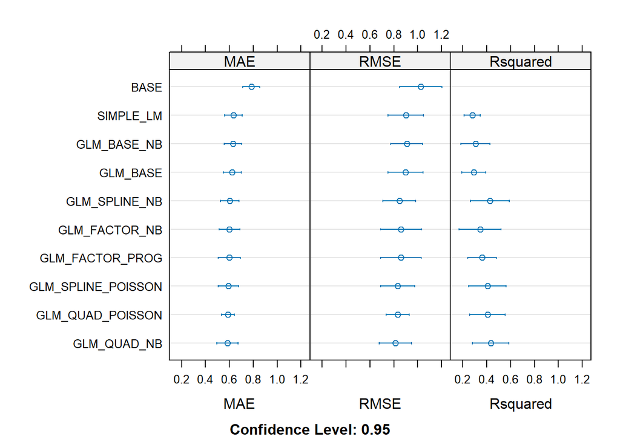

```r
# Plot the new comparison
dotplot(model_list)
```

# Verbal summary final (1p):

The 10-fold cross-validation results allow us to objectively compare each model’s predictive performance, with lower RMSE (Root Mean Squared Error) and MAE (Mean Absolute Error) indicating a better model.

#### Baseline vs. Simple Models:

The BASE null model (Mean RMSE: 1.024) was the worst performer. Adding the predictors, even incorrectly, in SIMPLE_LM (0.900) and GLM_BASE (0.896) provided a significant improvement, confirming the predictors are useful. The Poisson GLM_BASE performed almost identically to the SIMPLE_LM at this stage. Same also preforms GLM_BASE_NB which uses negative bionomial (0.907).

#### Fixing prog (Categorical):

Treating prog as a factor offered a small but consistent improvement.

```
GLM_BASE (RMSE: 0.896) → GLM_FACTOR_PROG (RMSE: 0.859)
GLM_BASE_NB (RMSE: 0.907) → GLM_FACTOR_NB (RMSE: 0.860)
```

This confirms that modeling prog as distinct categories is the correct approach.

#### Fixing work (Non-linear):

```
GLM_FACTOR_PROG (RMSE: 0.859) → GLM_QUAD_POISSON (RMSE: 0.832)
GLM_FACTOR_NB (RMSE: 0.860) → GLM_QUAD_NB (RMSE: 0.811)

GLM_FACTOR_PROG (RMSE: 0.859) → GLM_SPLINE_POISSON (RMSE: 0.831)
GLM_FACTOR_NB (RMSE: 0.860) → GLM_SPLINE_NB (RMSE: 0.845)
```

Comparing all 10 models, the best-performing models are clearly those that treat prog as a factor and work as non-linear.

```
TOP MODELS:
NAME                MEAN RMSE        MEAN MAE
GLM_QUAD_NB           0.811           0.583
GLM_QUAD_POISSON      0.832           0.587
GLM_SPLINE_POISSON    0.831           0.590
GLM_SPLINE_NB         0.845           0.602
```

```r
# Create a list of final models for AIC comparison
final_models <- list(
  SIMPLE_LM = m_lm$finalModel,
  GLM_BASE = m_glm_base$finalModel,
  GLM_BASE_NB = m_nb$finalModel,
  GLM_FACTOR_NB = m_nb_factor$finalModel,
  GLM_FACTOR_PROG = m_glm_factor$finalModel,
  GLM_QUAD_POISSON = m_glm_quad$finalModel,
  GLM_QUAD_NB = m_nb_quad$finalModel,
  GLM_SPLINE_POISSON = m_glm_spline$finalModel,
  GLM_SPLINE_NB = m_nb_spline$finalModel
)

# Extract AIC values
aic_values <- sapply(final_models, AIC)
aic_values
```

```
##          SIMPLE_LM           GLM_BASE        GLM_BASE_NB      GLM_FACTOR_NB
##           538.7950           386.8224           384.9361           375.1046
##    GLM_FACTOR_PROG   GLM_QUAD_POISSON        GLM_QUAD_NB GLM_SPLINE_POISSON
##           374.9967           362.3401           364.2927           364.6572
##      GLM_SPLINE_NB
##           365.9262
```

The AIC values from our model comparison provide strong evidence for the superiority of the properly specified GLMs over the simple linear model. The simple linear model had the highest AIC (538.8), indicating the poorest fit. Both the base Poisson (AIC: 386.8) and Negative Binomial (AIC: 384.9) models showed substantial improvements.

It is important to note that when running the 10-fold CV with different random seeds, the exact top spot may fluctuate between the GLM_QUAD_NB, GLM_SPLINE_NB, GLM_QUAD_POISSON and GLM_SPLINE_POISSON. However, the main conclusion remains consistent: the best-performing models are always those that correctly treat prog as a factor and work as non-linear, with the quadratic and spline models performing similarly.